# Data Exploration and Plots

Eugenie

02/07/2019

# 1 Plots

Load data. Please check the file path.

```r
reviews2.csv <- read.csv('/Users/yujinglai/Documents/Reviews2019/data/doc2vec_7/arslan-reviews2.csv')
```

Turn numeric values to factors.

```r
## turn numeric values to factors
reviews2.csv$is_deleted <- as.factor(reviews2.csv$is_deleted)
reviews2.csv$incentivized <- as.factor(reviews2.csv$incentivized)
reviews2.csv$verified_purchaser <- as.factor(reviews2.csv$verified_purchaser)

## change level values
levels(reviews2.csv$verified_purchaser) <- c("unverified", "verified")
levels(reviews2.csv$incentivized) <- c("non-incentivized", "incentivized")
levels(reviews2.csv$is_deleted) <- c("kept", "deleted")
```

## 1.1 Plot incentivized vs. non-incentivized reviews

[interactive chart not shown]

## 1.2 Rating distribution by group

Get the mean of incentivized vs. non-incentivized reviews

```r
aggregate(reviews2.csv[, 'rating'], list(reviews2.csv$incentivized), mean)
```

```
##            Group.1        x
## 1 non-incentivized 4.299104
## 2     incentivized 4.767962
```

Get the mean of is_deleted vs. non-deleted reviews

```r
aggregate(reviews2.csv[, 'rating'], list(reviews2.csv$is_deleted), mean)
```

```
##   Group.1        x
## 1    kept 4.278604
## 2 deleted 4.628630
```

Get the mean of verified_purchaser vs. non-verified_purchaser reviews

```r
aggregate(reviews2.csv[, 'rating'], list(reviews2.csv$verified_purchaser), mean)
```

```
##      Group.1        x
## 1 unverified 4.332709
## 2   verified 4.300275
```

[interactive chart not shown]

## 1.3 Group distribution

### 1.3.1 Group distribution stats

#### 1.3.1.1 Stats sub-grouped by verified reviews

Counts sub-grouped by verified reviews.

```
## , , verified_purchaser = unverified
##
##                   is_deleted
## incentivized         kept deleted
##   non-incentivized  14024    1946
##   incentivized        179    1461
##
## , , verified_purchaser = verified
##
##                   is_deleted
## incentivized         kept deleted
##   non-incentivized 232228   14450
##   incentivized         87     152
```

Percentage sub-grouped by verified reviews.

```
## , , verified_purchaser = unverified
##
##                   is_deleted
## incentivized            kept   deleted
##   non-incentivized 79.636570 11.050539
##   incentivized      1.016468  8.296422
##
## , , verified_purchaser = verified
##
##                   is_deleted
## incentivized              kept    deleted
##   non-incentivized 94.05103739 5.85216895
##   incentivized      0.03523451 0.06155915
```

It’s interesting that:

- A much higher percentage of incentivized reviews are made by unverified purchasers compared to verified (looking at the bottom row of the two tables)
- If you are a verified purchaser, your non-incentivized reviews are more likely to be kept (94.051% vs. 79.637%)
- A higher percentage of non-incentivized reviews from unverified purchasers (11.051%) are deleted than those from verified purchasers (5.852%)
- A higher percentage of incentivized reviews from unverified purchasers (1.016%) are kept than those from verified purchasers (0.035%)

The following stats (sub-grouped by the other two review categories and distribution by every combination of the groups) are for verifying the findings.

#### 1.3.1.2 Stats sub-grouped by deleted reviews

Percentage sub-grouped by is_deleted

```
## , , is_deleted = kept
##
##                   incentivized
## verified_purchaser non-incentivized incentivized
##         unverified         5.688834   0.07261133
##         verified          94.203263   0.03529154
##
## , , is_deleted = deleted
##
##                   incentivized
## verified_purchaser non-incentivized incentivized
##         unverified         10.80571    8.1126104
##         verified           80.23766    0.8440224
```

#### 1.3.1.3 Stats sub-grouped by incentivized reviews

Percentage sub-grouped by incentivized

```
## , , incentivized = non-incentivized
##
##                   is_deleted
## verified_purchaser      kept   deleted
##         unverified  5.339466 0.7409156
##         verified   88.417959 5.5016600
##
## , , incentivized = incentivized
##
##                   is_deleted
## verified_purchaser     kept   deleted
##         unverified 9.526344 77.754125
##         verified   4.630122  8.089409
```

#### 1.3.1.4 Percentage of each group

```
##       incentivized is_deleted verified_purchaser   Freq    Freq_pct
## 1 non-incentivized       kept         unverified  14024  5.30153822
## 2 non-incentivized       kept           verified 232228 87.78990424
## 3 non-incentivized    deleted         unverified   1946  0.73565269
## 4 non-incentivized    deleted           verified  14450  5.46258038
## 5     incentivized       kept         unverified    179  0.06766795
## 6     incentivized       kept           verified     87  0.03288889
## 7     incentivized    deleted         unverified   1461  0.55230657
## 8     incentivized    deleted           verified    152  0.05746105
```

### 1.3.2 Plots for group distribution

#### 1.3.2.1 Mosaic plots to visualize all three categories

Plot three groups together with a mosaic plot with facets on verified reviews

[interactive chart not shown]

Plot three groups together with a mosaic plot

[interactive chart not shown]

#### 1.3.2.2 Bar charts to visualize the combination of any two categories

Plot the proportion of deleted reviews in non-/incentivized group

[interactive chart not shown]

Plot the proportion of verified reviews in non-/incentivized group

[interactive chart not shown]

Plot the proportion of verified reviews in non-/deleted group

[interactive chart not shown]

## 1.4 Group Correlation

### 1.4.1 Chi-square tests on pairs of the three groups

Incentivized vs. is_deleted

```r
chisq.test(reviews2.csv$incentivized, reviews2.csv$is_deleted, correct = FALSE)
```

```
##
##  Pearson's Chi-squared test
##
## data:  reviews2.csv$incentivized and reviews2.csv$is_deleted
## X-squared = 18632, df = 1, p-value < 2.2e-16
```

Incentivized vs. verified_purchaser

```r
chisq.test(reviews2.csv$incentivized, reviews2.csv$verified_purchaser, correct = FALSE)
```

```
##
##  Pearson's Chi-squared test
##
## data:  reviews2.csv$incentivized and reviews2.csv$verified_purchaser
## X-squared = 19796, df = 1, p-value < 2.2e-16
```

Is_deleted vs. verified_purchaser

```r
chisq.test(reviews2.csv$is_deleted, reviews2.csv$verified_purchaser, correct = FALSE)
```

```
##
##  Pearson's Chi-squared test
##
## data:  reviews2.csv$is_deleted and reviews2.csv$verified_purchaser
## X-squared = 4675.2, df = 1, p-value < 2.2e-16
```

From the tests above, there correlation between the pairs are significant. Is there a way to find out the correlation between three categorical variables?

### 1.4.2 Effect size

Goodman and Kruskal’s tau to calculate the effect size (strength of association). Although the results of chi-square tests suggest the significance of the association between the groups, the effect size result shows they are not good predictors of one another.

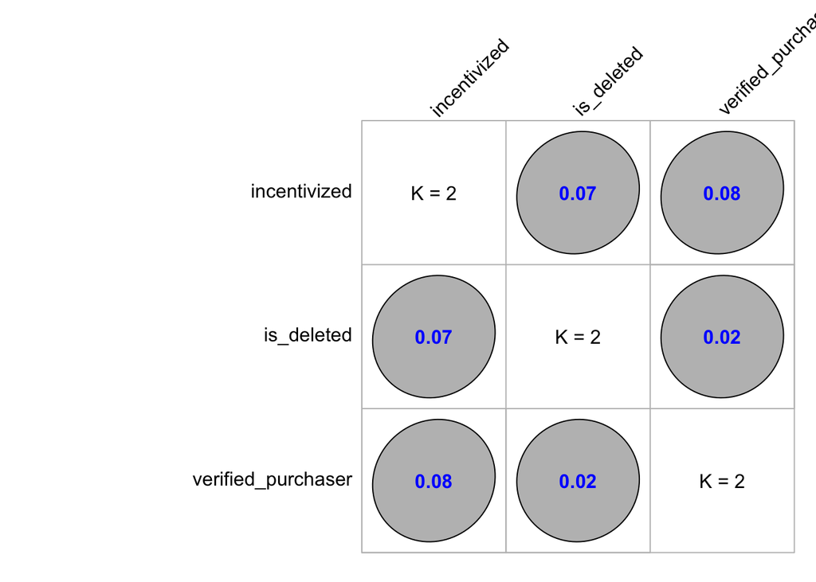

```r
reviews2.temp <- reviews2.csv[,c('incentivized', 'is_deleted', 'verified_purchaser')]
GKmatrix1<- GKtauDataframe(reviews2.temp)
plot(GKmatrix1, corrColors = "blue")
```

# 2 Models and Tests

## 2.1 Formula

```r
formula.fe <- rating ~ incentivized + is_deleted + verified_purchaser
```

## 2.2 linear fixed effect model for review2.csv

```r
# in model.fe, index = c('item_id') defines 'item_id' as the entity
model.fe <- plm(data = reviews2.csv, formula = formula.fe, index = c('item_id'), model = 'within')
# get the model summary
summary(model.fe)
```

```
## Oneway (individual) effect Within Model
##
## Call:
## plm(formula = formula.fe, data = reviews2.csv, model = "within",
##     index = c("item_id"))
##
## Unbalanced Panel: n = 101, T = 29-10148, N = 264527
##
## Residuals:
##     Min.  1st Qu.   Median  3rd Qu.     Max.
## -4.02659 -0.19783  0.47729  0.73617  3.03895
##
## Coefficients:
##                            Estimate Std. Error t-value  Pr(>|t|)
## incentivizedincentivized   0.491584   0.031709  15.503 < 2.2e-16 ***
## is_deleteddeleted          0.182913   0.010549  17.339 < 2.2e-16 ***
## verified_purchaserverified 0.086976   0.010728   8.107  5.21e-16 ***
## ---
## Signif. codes:  0 '***' 0.001 '**' 0.01 '*' 0.05 '.' 0.1 ' ' 1
##
## Total Sum of Squares:    423180
## Residual Sum of Squares: 422040
## R-Squared:      0.0027042
## Adj. R-Squared: 0.0023158
## F-statistic: 239.001 on 3 and 264423 DF, p-value: < 2.22e-16
```